# DA5020.A10.Zunqiu.Wang

Zunqiu Wang

11/22/2021

Q1  
conficence interval (CI): a good interval to estimate the mean of a target variable without knowing true population parameter. For instance, the 95% of CI of new born weight is 6lb to 9lb meaning we are 95% confident to conclude that mean weight of new born population will fall within this range. PI: a good interval to estimate the a future target variable wll fall, given a sets of current observations/statistical parameters. For example, given multiple pedictors for a linear regression model, we train the model with values of predictors and predict a prediction interval of 6lb to 8.5lb. We can say that 95% confidence that birth weight of next baby provided with same model will lie in this range. Generally, PI is much wider than CI since it is more challenging to estimate an individual value instead of mean of population. When we want to know specific predicted value we need to calculate PI.

```r
library(openintro)
```

```r
library(psych)
library(ggplot2)
library(tidyverse)
library(dplyr)
library(reshape2)
library(mlr)
library(caret)
library(MASS)
library(leaps)

data("ncbirths")
```

Q2

```r
ncbirths
```

```
## # A tibble: 1,000 × 13
##     fage  mage mature      weeks premie    visits marital gained weight lowbirthweight
##    <int> <int> <fct>       <int> <fct>      <int> <fct>    <int>  <dbl> <fct>
##  1    NA    13 younger mom    39 full term     10 not ma…     38   7.63 not low
##  2    NA    14 younger mom    42 full term     15 not ma…     20   7.88 not low
##  3    19    15 younger mom    37 full term     11 not ma…     38   6.63 not low
##  4    21    15 younger mom    41 full term      6 not ma…     34   8    not low
##  5    NA    15 younger mom    39 full term      9 not ma…     27   6.38 not low
##  6    NA    15 younger mom    38 full term     19 not ma…     22   5.38 low
##  7    18    15 younger mom    37 full term     12 not ma…     76   8.44 not low
##  8    17    15 younger mom    35 premie         5 not ma…     15   4.69 low
##  9    NA    16 younger mom    38 full term      9 not ma…     NA   8.81 not low
## 10    20    16 younger mom    37 full term     13 not ma…     52   6.94 not low
## # … with 990 more rows, and 3 more variables: gender <fct>, habit <fct>,
## #   whitemom <fct>
```

```r
# check variable type
str(ncbirths)
```

```
## tibble [1,000 × 13] (S3: tbl_df/tbl/data.frame)
##  $ fage          : int [1:1000] NA NA 19 21 NA NA 18 17 NA 20 ...
##  $ mage          : int [1:1000] 13 14 15 15 15 15 15 15 16 16 ...
##  $ mature        : Factor w/ 2 levels "mature mom","younger mom": 2 2 2 2 2 2 2 2 2 2 ...
##  $ weeks         : int [1:1000] 39 42 37 41 39 38 37 35 38 37 ...
##  $ premie        : Factor w/ 2 levels "full term","premie": 1 1 1 1 1 1 1 2 1 1 ...
##  $ visits        : int [1:1000] 10 15 11 6 9 19 12 5 9 13 ...
##  $ marital       : Factor w/ 2 levels "not married",..: 1 1 1 1 1 1 1 1 1 1 ...
##  $ gained        : int [1:1000] 38 20 38 34 27 22 76 15 NA 52 ...
##  $ weight        : num [1:1000] 7.63 7.88 6.63 8 6.38 5.38 8.44 4.69 8.81 6.94 ...
##  $ lowbirthweight: Factor w/ 2 levels "low","not low": 2 2 2 2 2 1 2 1 2 2 ...
##  $ gender        : Factor w/ 2 levels "female","male": 2 2 1 2 1 2 2 2 2 1 ...
##  $ habit         : Factor w/ 2 levels "nonsmoker","smoker": 1 1 1 1 1 1 1 1 1 1 ...
##  $ whitemom      : Factor w/ 2 levels "not white","white": 1 1 2 2 1 1 1 1 2 2 ...
```

```r
summary(ncbirths)
```

```
##       fage            mage            mature        weeks             premie
##  Min.   :14.00   Min.   :13   mature mom :133   Min.   :20.00   full term:846
##  1st Qu.:25.00   1st Qu.:22   younger mom:867   1st Qu.:37.00   premie   :152
##  Median :30.00   Median :27                     Median :39.00   NA's     :  2
##  Mean   :30.26   Mean   :27                     Mean   :38.33
##  3rd Qu.:35.00   3rd Qu.:32                     3rd Qu.:40.00
##  Max.   :55.00   Max.   :50                     Max.   :45.00
##  NA's   :171                                    NA's   :2
##      visits            marital        gained          weight
##  Min.   : 0.0   not married:386   Min.   : 0.00   Min.   : 1.000
##  1st Qu.:10.0   married    :613   1st Qu.:20.00   1st Qu.: 6.380
##  Median :12.0   NA's       :  1   Median :30.00   Median : 7.310
##  Mean   :12.1                     Mean   :30.33   Mean   : 7.101
##  3rd Qu.:15.0                     3rd Qu.:38.00   3rd Qu.: 8.060
##  Max.   :30.0                     Max.   :85.00   Max.   :11.750
##  NA's   :9                        NA's   :27
##  lowbirthweight    gender          habit          whitemom
##  low    :111    female:503   nonsmoker:873   not white:284
##  not low:889    male  :497   smoker   :126   white    :714
##                              NA's     :  1   NA's     :  2
##
##
##
##
```

```r
#check if NA
colSums(is.na(ncbirths))
```

```
##           fage           mage         mature          weeks         premie
##            171              0              0              2              2
##         visits        marital         gained         weight lowbirthweight
##              9              1             27              0              0
##         gender          habit       whitemom
##              0              1              2
```

```r
# impute NA
## impute numerical var with median
ncbirths <- ncbirths %>%
  mutate_if(is.numeric, function(x) ifelse(is.na(x), median(x, na.rm = T), x))

## impute categorical var with mode
get_mode <- function(x){
  uniq_val <- unique(x)
  count_unique <- tabulate(match(x, uniq_val))
  uniq_val[which.max(count_unique)]
}

###premie
ncbirths$premie[is.na(ncbirths$premie)] <- get_mode(ncbirths$premie)


### marital
ncbirths$marital[is.na(ncbirths$marital)] <- get_mode(ncbirths$marital)

### habit
ncbirths$habit[is.na(ncbirths$habit)] <- get_mode(ncbirths$habit)

### whitemom
ncbirths$whitemom[is.na(ncbirths$whitemom)] <- get_mode(ncbirths$whitemom)

str(ncbirths)
```

```
## tibble [1,000 × 13] (S3: tbl_df/tbl/data.frame)
##  $ fage          : int [1:1000] 30 30 19 21 30 30 18 17 30 20 ...
##  $ mage          : int [1:1000] 13 14 15 15 15 15 15 15 16 16 ...
##  $ mature        : Factor w/ 2 levels "mature mom","younger mom": 2 2 2 2 2 2 2 2 2 2 ...
##  $ weeks         : num [1:1000] 39 42 37 41 39 38 37 35 38 37 ...
##  $ premie        : Factor w/ 2 levels "full term","premie": 1 1 1 1 1 1 1 2 1 1 ...
##  $ visits        : int [1:1000] 10 15 11 6 9 19 12 5 9 13 ...
##  $ marital       : Factor w/ 2 levels "not married",..: 1 1 1 1 1 1 1 1 1 1 ...
##  $ gained        : int [1:1000] 38 20 38 34 27 22 76 15 30 52 ...
##  $ weight        : num [1:1000] 7.63 7.88 6.63 8 6.38 5.38 8.44 4.69 8.81 6.94 ...
##  $ lowbirthweight: Factor w/ 2 levels "low","not low": 2 2 2 2 2 1 2 1 2 2 ...
##  $ gender        : Factor w/ 2 levels "female","male": 2 2 1 2 1 2 2 2 2 1 ...
##  $ habit         : Factor w/ 2 levels "nonsmoker","smoker": 1 1 1 1 1 1 1 1 1 1 ...
##  $ whitemom      : Factor w/ 2 levels "not white","white": 1 1 2 2 1 1 1 1 2 2 ...
```

```r
summary(ncbirths)
```

```
##       fage            mage            mature        weeks             premie
##  Min.   :14.00   Min.   :13   mature mom :133   Min.   :20.00   full term:848
##  1st Qu.:26.00   1st Qu.:22   younger mom:867   1st Qu.:37.00   premie   :152
##  Median :30.00   Median :27                     Median :39.00
##  Mean   :30.21   Mean   :27                     Mean   :38.34
##  3rd Qu.:34.00   3rd Qu.:32                     3rd Qu.:40.00
##  Max.   :55.00   Max.   :50                     Max.   :45.00
##      visits            marital        gained          weight
##  Min.   : 0.0   not married:386   Min.   : 0.00   Min.   : 1.000
##  1st Qu.:10.0   married    :614   1st Qu.:21.00   1st Qu.: 6.380
##  Median :12.0                     Median :30.00   Median : 7.310
##  Mean   :12.1                     Mean   :30.32   Mean   : 7.101
##  3rd Qu.:15.0                     3rd Qu.:38.00   3rd Qu.: 8.060
##  Max.   :30.0                     Max.   :85.00   Max.   :11.750
##  lowbirthweight    gender          habit          whitemom
##  low    :111    female:503   nonsmoker:874   not white:284
##  not low:889    male  :497   smoker   :126   white    :716
##
##
##
##
```

```r
#check if NA again
colSums(is.na(ncbirths))
```

```
##           fage           mage         mature          weeks         premie
##              0              0              0              0              0
##         visits        marital         gained         weight lowbirthweight
##              0              0              0              0              0
##         gender          habit       whitemom
##              0              0              0
```

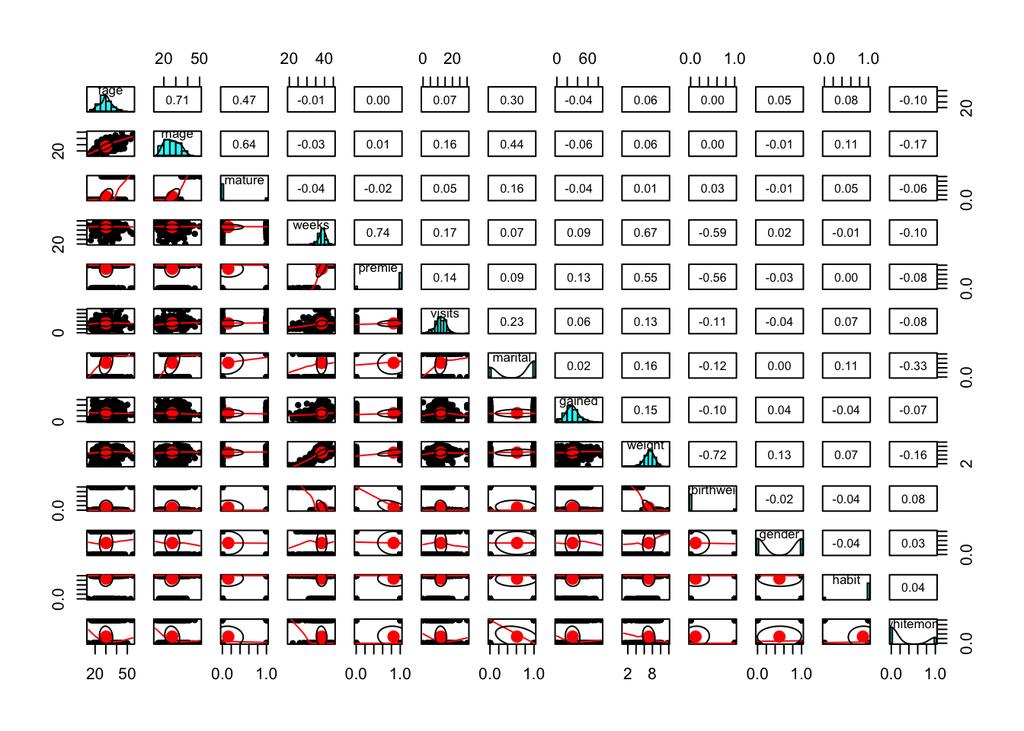

```r
# convert catogorical var to binary var
ncbirths$mature <- ifelse(ncbirths$mature == "mature mom",1,0)
ncbirths$premie <- ifelse(ncbirths$premie == "full term",1,0)
ncbirths$marital <- ifelse(ncbirths$marital == "married",1,0)
ncbirths$lowbirthweight <- ifelse(ncbirths$lowbirthweight == "low",1,0)
ncbirths$gender <- ifelse(ncbirths$gender == "male",1,0)
ncbirths$habit <- ifelse(ncbirths$habit == "nonsmoker",1,0)
ncbirths$whitemom <- ifelse(ncbirths$whitemom == "not white",1,0)

# cor matrix
pairs.panels(ncbirths)
```

```r
## using caret package findCorrelation() to find var of possible multicollinearity with defined cutoff correration value
cutoff <- 0.60
correlations <- cor(ncbirths)
highlyCorrelated <- findCorrelation(correlations, cutoff=cutoff)
for (value in highlyCorrelated) {
  print(names(ncbirths)[value])
  }
```

```
## [1] "weight"
## [1] "weeks"
## [1] "mage"
```

Inspection of correlation matrix reveals that there are several predictors may exist multicollinearity in the model. Could take a look at each class distribution of binary variables, which could raise imblanced classification (not consider here). - First of all, looking at distribution of each variables: + Normal distribution: father age, visits, gained, weight + Uniform distribution: mother age, gender + Skewed distribution: weeks (most are between 37 and 40), mature (mostly younger mom), premie (mostly full-term), lowbirthweight (mostly not low), habit(mostly non-smoker), whitemom (mostly whitemom) - multicollinearity: + 0.71 for fage and mage + 0.64 for mage and mature + 0.74 for weeks and premie + 0.55 for premie and weight + 0.67 for weeks and weight In general, high multicollinearity could affect p-value and coefficients when being used in the model. However, it wont affect predictions or goodness of fit. Some variables such as mature since its correlation with weight is only 0.01.

Q3

```r
full_weight_model <- lm(weight ~ fage + mage + mature + weeks + premie + visits + marital + gained + lowbirthweight + gender + habit + whitemom, data = ncbirths)

summary(full_weight_model)
```

```
##
## Call:
## lm(formula = weight ~ fage + mage + mature + weeks + premie +
##     visits + marital + gained + lowbirthweight + gender + habit +
##     whitemom, data = ncbirths)
##
## Residuals:
##     Min      1Q  Median      3Q     Max
## -2.4634 -0.6133 -0.0269  0.5553  3.9788
##
## Coefficients:
##                 Estimate Std. Error t value Pr(>|t|)
## (Intercept)    -0.932561   0.585568  -1.593 0.111576
## fage            0.008648   0.006673   1.296 0.195255
## mage            0.003614   0.008244   0.438 0.661180
## mature          0.009978   0.112521   0.089 0.929355
## weeks           0.192155   0.015451  12.436  < 2e-16 ***
## premie         -0.008785   0.122673  -0.072 0.942923
## visits         -0.002369   0.007679  -0.308 0.757802
## marital         0.086001   0.071157   1.209 0.227100
## gained          0.006911   0.002085   3.314 0.000952 ***
## lowbirthweight -2.312349   0.117085 -19.749  < 2e-16 ***
## gender          0.347528   0.058090   5.983 3.07e-09 ***
## habit           0.264192   0.088063   3.000 0.002767 **
## whitemom       -0.233306   0.068304  -3.416 0.000662 ***
## ---
## Signif. codes:  0 '***' 0.001 '**' 0.01 '*' 0.05 '.' 0.1 ' ' 1
##
## Residual standard error: 0.91 on 987 degrees of freedom
## Multiple R-squared:  0.6406, Adjusted R-squared:  0.6363
## F-statistic: 146.6 on 12 and 987 DF,  p-value: < 2.2e-16
```

```r
#residual standard error rate
sigma(full_weight_model)/mean(ncbirths$weight)
```

```
## [1] 0.1281509
```

The Multiple R-squared is 0.6406 and Adjusted R-squared 0.6363 meaning most variables are explained by the model as they dont differ much. The residual standard error (RSE) is 0.91 and I calculate the error rate, which is 13%. Not bad The F-statistic is 146.6 , p-value is < 2.2e-16 indicating statistically signifcant. For individual p-values of coefficients, there are few values greater than 0.05 and they are not statistically significant in the model. They are fage, mage, mature, premie, visits and marital. The other variables such as weeks, gained, lowbirthweight, gender, habit, and whitemom are statistically significant.

Q4

```r
# using stepAIC() from MASS to automatically doing stepwise elimination
step.model1 <- stepAIC(full_weight_model, direction = "backward")
```

```
## Start:  AIC=-175.71
## weight ~ fage + mage + mature + weeks + premie + visits + marital +
##     gained + lowbirthweight + gender + habit + whitemom
##
##                  Df Sum of Sq     RSS     AIC
## - premie          1      0.00  817.34 -177.70
## - mature          1      0.01  817.34 -177.70
## - visits          1      0.08  817.41 -177.61
## - mage            1      0.16  817.49 -177.51
## - marital         1      1.21  818.54 -176.23
## - fage            1      1.39  818.73 -176.01
## <none>                         817.33 -175.71
## - habit           1      7.45  824.79 -168.63
## - gained          1      9.10  826.43 -166.64
## - whitemom        1      9.66  827.00 -165.96
## - gender          1     29.64  846.97 -142.09
## - weeks           1    128.07  945.41  -32.14
## - lowbirthweight  1    322.99 1140.32  155.31
##
## Step:  AIC=-177.7
## weight ~ fage + mage + mature + weeks + visits + marital + gained +
##     lowbirthweight + gender + habit + whitemom
##
##                  Df Sum of Sq     RSS     AIC
## - mature          1      0.01  817.35 -179.69
## - visits          1      0.08  817.42 -179.60
## - mage            1      0.16  817.50 -179.51
## - marital         1      1.21  818.55 -178.22
## - fage            1      1.39  818.73 -178.00
## <none>                         817.34 -177.70
## - habit           1      7.46  824.79 -170.62
## - gained          1      9.14  826.47 -168.59
## - whitemom        1      9.67  827.01 -167.94
## - gender          1     29.84  847.18 -143.84
## - weeks           1    200.23 1017.57   39.42
## - lowbirthweight  1    340.03 1157.37  168.15
##
## Step:  AIC=-179.69
## weight ~ fage + mage + weeks + visits + marital + gained + lowbirthweight +
##     gender + habit + whitemom
```

[output cut: 29 more lines]

```
##
## Step:  AIC=-183.31
## weight ~ fage + weeks + marital + gained + lowbirthweight + gender +
##     habit + whitemom
##
##                  Df Sum of Sq     RSS     AIC
## <none>                         817.66 -183.31
## - marital         1      1.64  819.30 -183.30
## - fage            1      4.28  821.94 -180.09
## - habit           1      7.53  825.20 -176.13
## - gained          1      8.94  826.60 -174.43
## - whitemom        1      9.86  827.52 -173.32
## - gender          1     29.80  847.47 -149.50
## - weeks           1    202.86 1020.53   36.32
## - lowbirthweight  1    340.08 1157.74  162.47
```

```r
summary(step.model1)
```

```
##
## Call:
## lm(formula = weight ~ fage + weeks + marital + gained + lowbirthweight +
##     gender + habit + whitemom, data = ncbirths)
##
## Residuals:
##     Min      1Q  Median      3Q     Max
## -2.4822 -0.6054 -0.0192  0.5521  3.9985
##
## Coefficients:
##                 Estimate Std. Error t value Pr(>|t|)
## (Intercept)    -0.890577   0.510185  -1.746 0.081191 .
## fage            0.011187   0.004914   2.276 0.023035 *
## weeks           0.190673   0.012160  15.680  < 2e-16 ***
## marital         0.092974   0.065901   1.411 0.158614
## gained          0.006803   0.002067   3.292 0.001031 **
## lowbirthweight -2.310248   0.113794 -20.302  < 2e-16 ***
## gender          0.346712   0.057687   6.010  2.6e-09 ***
## habit           0.264985   0.087694   3.022 0.002578 **
## whitemom       -0.235342   0.068074  -3.457 0.000569 ***
## ---
## Signif. codes:  0 '***' 0.001 '**' 0.01 '*' 0.05 '.' 0.1 ' ' 1
##
## Residual standard error: 0.9083 on 991 degrees of freedom
## Multiple R-squared:  0.6405, Adjusted R-squared:  0.6376
## F-statistic: 220.7 on 8 and 991 DF,  p-value: < 2.2e-16
```

```r
#using train() from caret to specify stepwise elimination
set.seed(1234)
train.control <- trainControl(method = "cv", number = 10)
step.model2 <- train(weight ~ fage + mage + mature + weeks + premie + visits + marital + gained + lowbirthweight + gender + habit + whitemom, data = ncbirths, method = "leapBackward", tuneGrid = data.frame(nvmax = 1:12), trControl = train.control)

step.model2$results
```

```
##    nvmax      RMSE  Rsquared       MAE     RMSESD RsquaredSD      MAESD
## 1      1 1.0491922 0.5177348 0.8423623 0.05477550 0.04483086 0.03416814
## 2      2 0.9422228 0.6077472 0.7561908 0.07092549 0.06446456 0.05034334
## 3      3 0.9264576 0.6211381 0.7394231 0.07779999 0.06666671 0.05906214
## 4      4 0.9227174 0.6245088 0.7369255 0.08419694 0.06942693 0.06581366
## 5      5 0.9239142 0.6236509 0.7374966 0.08333775 0.06977542 0.06508322
## 6      6 0.9176068 0.6286569 0.7315890 0.08200120 0.06653785 0.06669937
## 7      7 0.9113949 0.6334688 0.7287807 0.08704960 0.06802290 0.06973011
## 8      8 0.9099427 0.6345383 0.7292076 0.08552877 0.06742187 0.06965591
## 9      9 0.9119045 0.6329801 0.7306086 0.08477091 0.06678290 0.06861834
## 10    10 0.9133218 0.6318333 0.7318157 0.08398035 0.06637782 0.06798651
## 11    11 0.9141519 0.6311632 0.7325384 0.08404349 0.06651364 0.06840890
## 12    12 0.9141867 0.6311245 0.7324991 0.08401042 0.06654313 0.06835555
```

```r
step.model2$bestTune
```

```
##   nvmax
## 8     8
```

```r
summary(step.model2$finalModel)
```

```
## Subset selection object
## 12 Variables  (and intercept)
##                Forced in Forced out
## fage               FALSE      FALSE
## mage               FALSE      FALSE
## mature             FALSE      FALSE
## weeks              FALSE      FALSE
## premie             FALSE      FALSE
## visits             FALSE      FALSE
## marital            FALSE      FALSE
## gained             FALSE      FALSE
## lowbirthweight     FALSE      FALSE
## gender             FALSE      FALSE
## habit              FALSE      FALSE
## whitemom           FALSE      FALSE
## 1 subsets of each size up to 8
## Selection Algorithm: backward
##          fage mage mature weeks premie visits marital gained lowbirthweight
## 1  ( 1 ) " "  " "  " "    " "   " "    " "    " "     " "    "*"
## 2  ( 1 ) " "  " "  " "    "*"   " "    " "    " "     " "    "*"
## 3  ( 1 ) " "  " "  " "    "*"   " "    " "    " "     " "    "*"
## 4  ( 1 ) " "  " "  " "    "*"   " "    " "    " "     " "    "*"
## 5  ( 1 ) " "  " "  " "    "*"   " "    " "    " "     " "    "*"
## 6  ( 1 ) " "  " "  " "    "*"   " "    " "    " "     "*"    "*"
## 7  ( 1 ) "*"  " "  " "    "*"   " "    " "    " "     "*"    "*"
## 8  ( 1 ) "*"  " "  " "    "*"   " "    " "    "*"     "*"    "*"
##          gender habit whitemom
## 1  ( 1 ) " "    " "   " "
## 2  ( 1 ) " "    " "   " "
## 3  ( 1 ) "*"    " "   " "
## 4  ( 1 ) "*"    " "   "*"
## 5  ( 1 ) "*"    "*"   "*"
## 6  ( 1 ) "*"    "*"   "*"
## 7  ( 1 ) "*"    "*"   "*"
## 8  ( 1 ) "*"    "*"   "*"
```

```r
coef(step.model2$finalModel,4)
```

```
##    (Intercept)          weeks lowbirthweight         gender       whitemom
##     0.01025537     0.18936126    -2.36910287     0.35533519    -0.28957667
```

```r
# manually doing
## remove premie since its p value 0.943 is biggest, adjusted R^2 increased to 0.6366
step.model3 <- lm(weight ~ fage + mage + mature + weeks + visits + marital + gained + lowbirthweight + gender + habit + whitemom, data = ncbirths)
summary(step.model3)
```

```
##
## Call:
## lm(formula = weight ~ fage + mage + mature + weeks + visits +
##     marital + gained + lowbirthweight + gender + habit + whitemom,
##     data = ncbirths)
##
## Residuals:
##     Min      1Q  Median      3Q     Max
## -2.4610 -0.6144 -0.0275  0.5565  3.9781
##
## Coefficients:
##                 Estimate Std. Error t value Pr(>|t|)
## (Intercept)    -0.913894   0.524092  -1.744 0.081511 .
## fage            0.008658   0.006668   1.299 0.194407
## mage            0.003589   0.008232   0.436 0.662991
## mature          0.010106   0.112450   0.090 0.928410
## weeks           0.191487   0.012308  15.558  < 2e-16 ***
## visits         -0.002372   0.007675  -0.309 0.757322
## marital         0.085934   0.071115   1.208 0.227187
## gained          0.006897   0.002076   3.323 0.000923 ***
## lowbirthweight -2.310442   0.113962 -20.274  < 2e-16 ***
## gender          0.347825   0.057911   6.006 2.67e-09 ***
## habit           0.264234   0.088017   3.002 0.002749 **
## whitemom       -0.233396   0.068258  -3.419 0.000653 ***
## ---
## Signif. codes:  0 '***' 0.001 '**' 0.01 '*' 0.05 '.' 0.1 ' ' 1
##
## Residual standard error: 0.9095 on 988 degrees of freedom
## Multiple R-squared:  0.6406, Adjusted R-squared:  0.6366
## F-statistic: 160.1 on 11 and 988 DF,  p-value: < 2.2e-16
```

```r
## remove mature since its p value 0.928 is biggest for now, adjusted R^2 increased to 0.637
step.model4 <- lm(weight ~ fage + mage + weeks + visits + marital + gained + lowbirthweight + gender + habit + whitemom, data = ncbirths)
summary(step.model4)
```

```
##
## Call:
## lm(formula = weight ~ fage + mage + weeks + visits + marital +
##     gained + lowbirthweight + gender + habit + whitemom, data = ncbirths)
##
## Residuals:
##     Min      1Q  Median      3Q     Max
## -2.4606 -0.6143 -0.0243  0.5556  3.9750
##
## Coefficients:
##                 Estimate Std. Error t value Pr(>|t|)
## (Intercept)    -0.922684   0.514626  -1.793 0.073291 .
## fage            0.008677   0.006661   1.303 0.193037
## mage            0.003969   0.007057   0.562 0.573966
## weeks           0.191492   0.012302  15.566  < 2e-16 ***
## visits         -0.002398   0.007666  -0.313 0.754528
## marital         0.084953   0.070237   1.210 0.226751
## gained          0.006899   0.002075   3.326 0.000914 ***
## lowbirthweight -2.310293   0.113892 -20.285  < 2e-16 ***
## gender          0.347800   0.057882   6.009 2.62e-09 ***
## habit           0.264152   0.087968   3.003 0.002742 **
## whitemom       -0.233283   0.068212  -3.420 0.000652 ***
## ---
## Signif. codes:  0 '***' 0.001 '**' 0.01 '*' 0.05 '.' 0.1 ' ' 1
##
## Residual standard error: 0.9091 on 989 degrees of freedom
## Multiple R-squared:  0.6406, Adjusted R-squared:  0.637
## F-statistic: 176.3 on 10 and 989 DF,  p-value: < 2.2e-16
```

```r
## remove visits since its p value 0.754 is biggest for now, adjusted R^2 increased to 0.6373
step.model5 <- lm(weight ~ fage + mage + weeks + marital + gained + lowbirthweight + gender + habit + whitemom, data = ncbirths)
summary(step.model5)
```

```
##
## Call:
## lm(formula = weight ~ fage + mage + weeks + marital + gained +
##     lowbirthweight + gender + habit + whitemom, data = ncbirths)
##
## Residuals:
##     Min      1Q  Median      3Q     Max
## -2.4712 -0.6203 -0.0226  0.5492  3.9788
##
## Coefficients:
##                 Estimate Std. Error t value Pr(>|t|)
## (Intercept)    -0.924737   0.514350  -1.798 0.072501 .
## fage            0.008793   0.006648   1.323 0.186254
## mage            0.003755   0.007021   0.535 0.592893
## weeks           0.190955   0.012176  15.683  < 2e-16 ***
## marital         0.081496   0.069330   1.175 0.240087
## gained          0.006865   0.002071   3.315 0.000948 ***
## lowbirthweight -2.310574   0.113837 -20.297  < 2e-16 ***
## gender          0.348533   0.057808   6.029 2.32e-09 ***
## habit           0.262796   0.087821   2.992 0.002837 **
## whitemom       -0.233667   0.068170  -3.428 0.000634 ***
## ---
## Signif. codes:  0 '***' 0.001 '**' 0.01 '*' 0.05 '.' 0.1 ' ' 1
##
## Residual standard error: 0.9087 on 990 degrees of freedom
## Multiple R-squared:  0.6406, Adjusted R-squared:  0.6373
## F-statistic: 196.1 on 9 and 990 DF,  p-value: < 2.2e-16
```

```r
## remove mage since its p value 0.593 is biggest for now, adjusted R^2 increased to 0.6376, R^2 lowered to 0.6405
step.model6 <- lm(weight ~ fage + weeks + marital + gained + lowbirthweight + gender + habit + whitemom, data = ncbirths)
summary(step.model6)
```

```
##
## Call:
## lm(formula = weight ~ fage + weeks + marital + gained + lowbirthweight +
##     gender + habit + whitemom, data = ncbirths)
##
## Residuals:
##     Min      1Q  Median      3Q     Max
## -2.4822 -0.6054 -0.0192  0.5521  3.9985
##
## Coefficients:
##                 Estimate Std. Error t value Pr(>|t|)
## (Intercept)    -0.890577   0.510185  -1.746 0.081191 .
## fage            0.011187   0.004914   2.276 0.023035 *
## weeks           0.190673   0.012160  15.680  < 2e-16 ***
## marital         0.092974   0.065901   1.411 0.158614
## gained          0.006803   0.002067   3.292 0.001031 **
## lowbirthweight -2.310248   0.113794 -20.302  < 2e-16 ***
## gender          0.346712   0.057687   6.010  2.6e-09 ***
## habit           0.264985   0.087694   3.022 0.002578 **
## whitemom       -0.235342   0.068074  -3.457 0.000569 ***
## ---
## Signif. codes:  0 '***' 0.001 '**' 0.01 '*' 0.05 '.' 0.1 ' ' 1
##
## Residual standard error: 0.9083 on 991 degrees of freedom
## Multiple R-squared:  0.6405, Adjusted R-squared:  0.6376
## F-statistic: 220.7 on 8 and 991 DF,  p-value: < 2.2e-16
```

```r
## remove marital since its p value 0.158 is biggest for now, adjusted R^2 decreased to 0.6372, R^2 decreased to 0.6398, not improving from last model
step.model7 <- lm(weight ~ fage + weeks + gained + lowbirthweight + gender + habit + whitemom, data = ncbirths)
summary(step.model7)
```

```
##
## Call:
## lm(formula = weight ~ fage + weeks + gained + lowbirthweight +
##     gender + habit + whitemom, data = ncbirths)
##
## Residuals:
##     Min      1Q  Median      3Q     Max
## -2.4545 -0.6104 -0.0254  0.5628  3.9300
##
## Coefficients:
##                 Estimate Std. Error t value Pr(>|t|)
## (Intercept)    -0.885610   0.510427  -1.735 0.083045 .
## fage            0.013113   0.004723   2.776 0.005600 **
## weeks           0.190460   0.012165  15.656  < 2e-16 ***
## gained          0.006829   0.002068   3.303 0.000991 ***
## lowbirthweight -2.324400   0.113408 -20.496  < 2e-16 ***
## gender          0.346731   0.057716   6.008 2.64e-09 ***
## habit           0.278006   0.087251   3.186 0.001486 **
## whitemom       -0.265400   0.064686  -4.103 4.41e-05 ***
## ---
## Signif. codes:  0 '***' 0.001 '**' 0.01 '*' 0.05 '.' 0.1 ' ' 1
##
## Residual standard error: 0.9088 on 992 degrees of freedom
## Multiple R-squared:  0.6398, Adjusted R-squared:  0.6372
## F-statistic: 251.7 on 7 and 992 DF,  p-value: < 2.2e-16
```

At each step of elimination, the model is improving expect last one as adjusted R^2 is increasing. This signify that the better correlation between observed values of outcome variable and fitted values, and the large it is the better the model explain variance of outcome variable.

Q5

```r
coe <- coef(step.model7)
weight_model <- coe[1] + coe[2] * 40 + coe[3] * 42 + coe[4] * 22 + coe[5] *0 + coe[6] * 0 + coe[7] * 1 + coe[8] * 0
weight_model
```

```
## (Intercept)
##     8.06648
```

```r
pred_df <- data.frame(fage = 40, weeks = 42, gained = 22 ,lowbirthweight = 0 , gender = 0, habit = 1 , whitemom = 0)

pred_int_new <- predict(step.model7, newdata = pred_df, interval = "prediction")

conf_int_new <- predict(step.model7, newdata = pred_df, interval = "confidence")
```

The predicted weight is 8.06648. The 95% confidence interval is 7.915943 to 8.217017. The 95% prediction interval is 6.276752 to 9.856207. The prediction interval is wider than confident interval since more uncertainty will be added to predict a single value than a mean weight.